# Predicting the Intensity of an Exercise Using Machine Learning

Tejas Guha

July 30, 2017

## Introduction

Everyday, fitness trackers such as *Fitbit* or *Jawbone* track the quantity of activity. However, they do not track the *quality* of exercise done, which is equally as important as quantity. The purpose of the developed algorithm is to predict the intensity of an exercise done by a participant. The machine learning algorithm uses training data and testing data collected from https://d396qusza40orc.cloudfront.net/predmachlearn/pml-training.csv and https://d396qusza40orc.cloudfront.net/predmachlearn/pml-testing.csv.In the data set, this intensity is represented by the qualitative variable, *Classe*, which has 5 levels, A being the most intense, and E being the least. Data was collected from sensors on the participants’ hips, waist, and arms, and the dumbell being lifted.

## Analyzing the Data

Opening the training set we see that the data contains 160 features. Many of these features only contain missing or invalid observations. Additionally, the data contains features that should not be used in prediction, such as the user, and features irrelevant to prediction such as the window number. These features are removed.

```r
library(caret)
training = read.csv("pml-training.csv", na.strings=c('#DIV/0', '', 'NA'))
training = training[,8:160]
testing = read.csv("pml-testing.csv", na.strings=c('#DIV/0', ' ', 'NA'))
testing = testing[,8:160]
training = training[,apply(training,2, function(x) !anyNA(x))]
testing = testing[,apply(testing,2, function(x) !anyNA(x))]
head(training[,1:5])
```

```
##   roll_belt pitch_belt yaw_belt total_accel_belt gyros_belt_x
## 1      1.41       8.07    -94.4                3         0.00
## 2      1.41       8.07    -94.4                3         0.02
## 3      1.42       8.07    -94.4                3         0.00
## 4      1.48       8.05    -94.4                3         0.02
## 5      1.48       8.07    -94.4                3         0.02
## 6      1.45       8.06    -94.4                3         0.02
```

With now 53 features, the training set still has too many variables that would make any model run inefficiently. To remove the highly correlated variables, and reduce the number of variables, a PCA analysis was applied to the training set. The graph shows the distribution of the different classes, on the graph of the PC1 and PC2 set. The red lines indicate the relation a feature has to PC1 and PC2.

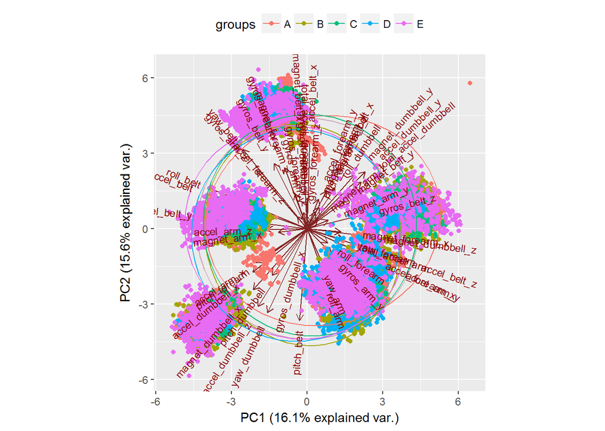

```r
library(ggbiplot)
pr= prcomp(training[,-53], center=TRUE, scale=TRUE)
g = ggbiplot(pr, obs.scale = 1, var.scale=1, ellipse=TRUE, circle=TRUE, groups = training$classe)
g = g + theme(legend.direction = 'horizontal', legend.position='top')
print(g)
```

## Building and Testing the Model

Other models were analyzed, such as a boosted LDA model, however, the accuracy of the random forest model was unmatched in this situtation. The random forest model was much faster with the randomForest package than the caret package, and computationally less stressing than the boosted LDA model. To test the random forest model, a 10-fold cross validation was done, with the accuracy and statistics of each model recorded in the data frame **stats**. Each fold in the cross validation was 1/10 of the size of the training set. The PCA analysis made the randomForest model much faster. The summary of the statistics of the model are displayed.

```r
library(randomForest)



preObj = preProcess(training[,-53],method=c("center","scale","pca"))
pca_data = predict(preObj, training[,-53])
set.seed(123)
confusion_matrices = list()
for (k in 1:10){
      set.seed(k)
      fold = unlist(createDataPartition(training$classe, p=0.1))
      fold_training = pca_data[-fold,]
      rf_fold_model = randomForest(training[-fold,]$classe ~ . , data=fold_training, ntree=100)
      pca_fold = na.omit(pca_data[fold,])
      rf_fold_predictions = predict(rf_fold_model, pca_fold)
      confusion = confusionMatrix(rf_fold_predictions, training[fold,]$classe)
      confusion_matrices[[k]] = confusion
}

header = names(confusion_matrices[[1]][[3]])
stats = apply(data.frame(rbind(lapply(header, function(x) lapply(confusion_matrices, function(y) y[[3]][[x]])))),2,unlist)
colnames(stats) = header
summary(stats)
```

```
##     Accuracy          Kappa        AccuracyLower    AccuracyUpper
##  Min.   :0.9776   Min.   :0.9717   Min.   :0.9700   Min.   :0.9837
##  1st Qu.:0.9786   1st Qu.:0.9729   1st Qu.:0.9712   1st Qu.:0.9845
##  Median :0.9809   Median :0.9758   Median :0.9738   Median :0.9865
##  Mean   :0.9808   Mean   :0.9757   Mean   :0.9737   Mean   :0.9863
##  3rd Qu.:0.9819   3rd Qu.:0.9771   3rd Qu.:0.9750   3rd Qu.:0.9873
##  Max.   :0.9847   Max.   :0.9807   Max.   :0.9783   Max.   :0.9897
##
##   AccuracyNull    AccuracyPValue McnemarPValue
##  Min.   :0.2841   Min.   :0      Min.   : NA
##  1st Qu.:0.2841   1st Qu.:0      1st Qu.: NA
##  Median :0.2841   Median :0      Median : NA
##  Mean   :0.2841   Mean   :0      Mean   :NaN
##  3rd Qu.:0.2841   3rd Qu.:0      3rd Qu.: NA
##  Max.   :0.2841   Max.   :0      Max.   : NA
##                                  NA's   :10
```